# Richard Vook CMSC320 Final

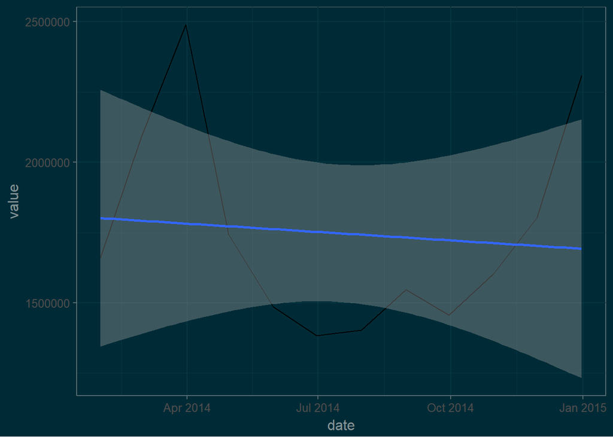

```r
nics_tidy %>%
  filter(year == "2014") %>%
  ggplot(aes(x = date, y = value, group=factor(year)))  +
  geom_path(stat = "identity") +
  geom_smooth(method=lm) +
  theme_solarized(light = FALSE) +
  scale_colour_solarized("red")
```

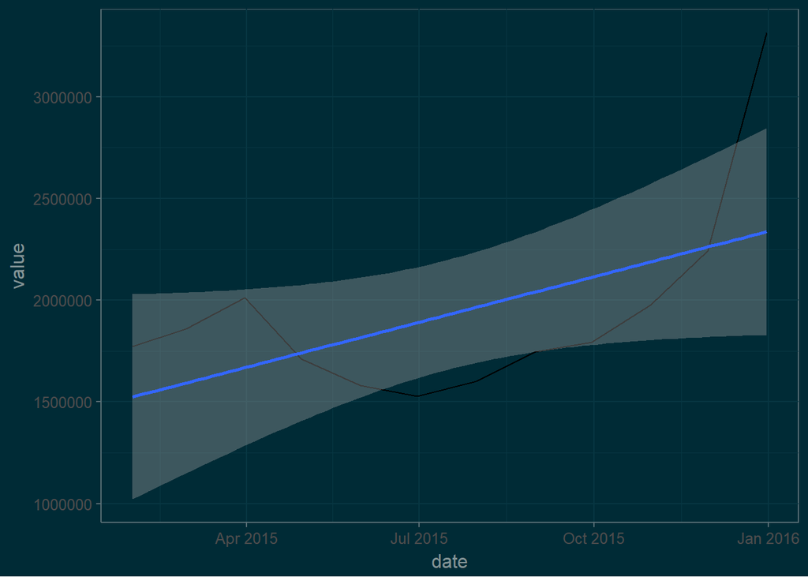

```r
nics_tidy %>%
  filter(year == "2015") %>%
  ggplot(aes(x = date, y = value, group=factor(year)))  +
  geom_path(stat = "identity") +
  geom_smooth(method=lm) +
  theme_solarized(light = FALSE) +
  scale_colour_solarized("red")
```

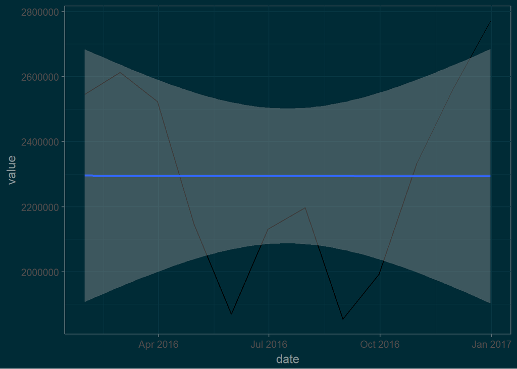

```r
nics_tidy %>%
  filter(year == "2016") %>%
  ggplot(aes(x = date, y = value, group=factor(year)))  +
  geom_path(stat = "identity") +
  geom_smooth(method=lm) +
  theme_solarized(light = FALSE) +
  scale_colour_solarized("red")
```

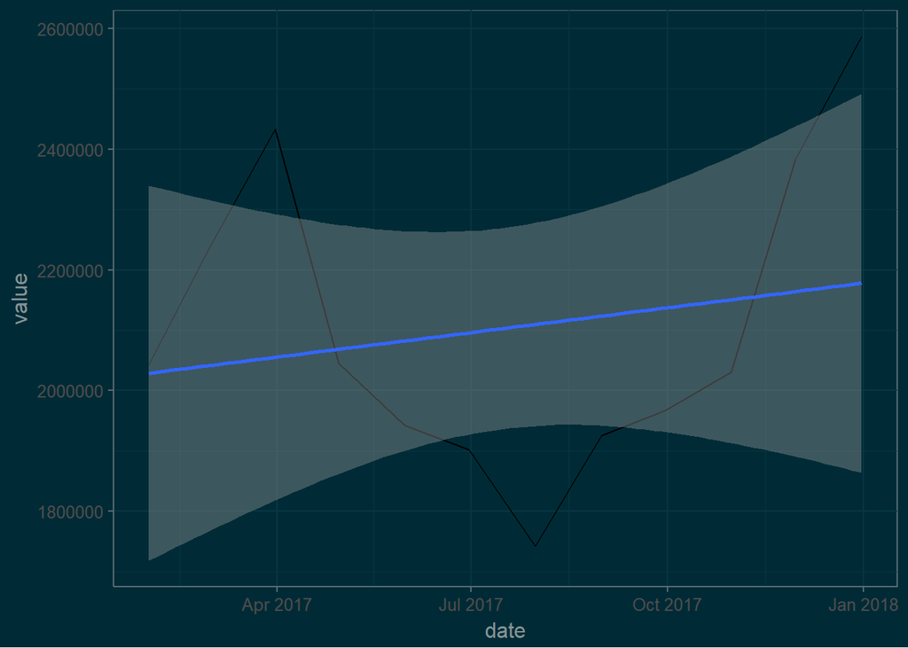

```r
nics_tidy %>%
  filter(year == "2017") %>%
  ggplot(aes(x = date, y = value, group=factor(year)))  +
  geom_path(stat = "identity") +
  geom_smooth(method=lm) +
  theme_solarized(light = FALSE) +
  scale_colour_solarized("red")
```

Continueing on with my Exploratory data analysis, I wanted to see if I could combine two of my data sets to show information about different states. I created a column in my nfa_items_by_state dataframe that counts the number of firearm traces in the year 2016. My goal with this is to potentially see which states possess more of certain firearms in crimes compared to what is legally owned by the state. Unfortunately, the trace data did not have a section for SBR’s and SBS’s so I used the catagory of rifles and shotguns in their place.

```r
nfa_items_by_state$state <- tolower(nfa_items_by_state$state)
nfa_items_by_state$state <- gsub('_', ' ', nfa_items_by_state$state)
trace_type_by_state_2016$STATE <- tolower(trace_type_by_state_2016$STATE)

nfa_items_by_state$aowtraces <- 0
nfa_items_by_state$ddtraces <- 0
nfa_items_by_state$mgtraces <- 0
nfa_items_by_state$sptraces <- 0
nfa_items_by_state$sbrtraces <- 0
nfa_items_by_state$sbstraces <- 0

for (i in seq(1, nrow(nfa_items_by_state))) {
  for (j in seq(1, nrow(trace_type_by_state_2016))) {
    if(!is.na(trace_type_by_state_2016$STATE[i]) & !is.na(nfa_items_by_state$state[j])&trace_type_by_state_2016$STATE[i] == nfa_items_by_state$state[j]){
        nfa_items_by_state$aowtraces[i] <- trace_type_by_state_2016$`ANY OTHER WEAPON`[j]
        nfa_items_by_state$ddtraces[i] <- trace_type_by_state_2016$`DESTRUCTIVE DEVICE`[j]
        nfa_items_by_state$mgtraces[i] <- trace_type_by_state_2016$MACHINEGUN[j]
        nfa_items_by_state$sptraces[i] <- trace_type_by_state_2016$SILENCER[j]
        nfa_items_by_state$sbrtraces[i] <- trace_type_by_state_2016$RIFLE[j]
        nfa_items_by_state$sbstraces[i] <- trace_type_by_state_2016$SHOTGUN[j]
    }
  }
}
datatable(nfa_items_by_state,filter="top",style="bootstrap")
```

|  | state | any_other_weapons | Dangerous_destructive_devices | Machine_guns | Supressors | short_barrel_rifles | short_barrel_shotguns | aowtraces | ddtraces | mgtraces | sptraces | sbrtraces | sbstraces |
| --- | --- | --- | --- | --- | --- | --- | --- | --- | --- | --- | --- | --- | --- |
| 1 | alabama | 1203 | 78434 | 26307 | 48118 | 5285 | 2294 | 9 | 3 | 24 | 2 | 736 | 437 |
| 2 | alaska | 327 | 4722 | 1650 | 6040 | 1783 | 1302 | 0 | 0 | 3 | 0 | 282 | 147 |
| 3 | arkansas | 620 | 49499 | 5319 | 19979 | 3266 | 1158 | 0 | 0 | 14 | 0 | 478 | 370 |
| 4 | arizona | 1277 | 105067 | 16874 | 40485 | 13695 | 2340 | 5 | 2 | 26 | 15 | 1377 | 812 |
| 5 | california | 3932 | 272128 | 29047 | 15044 | 10796 | 13675 | 7 | 12 | 114 | 15 | 7594 | 4280 |
| 6 | colorado | 997 | 47275 | 7206 | 28378 | 6804 | 1775 | 0 | 1 | 8 | 3 | 734 | 432 |
| 7 | connecticut | 911 | 12747 | 52965 | 10819 | 3951 | 1007 | 0 | 1 | 4 | 0 | 69 | 157 |
| 8 | district of columbia | 69 | 39733 | 5086 | 389 | 848 | 1103 | 0 | 0 | 0 | 0 | 116 | 104 |
| 9 | delaware | 32 | 3032 | 585 | 326 | 233 | 644 | 0 | 1 | 2 | 0 | 122 | 113 |
| 10 | florida | 3560 | 181734 | 36194 | 85998 | 27092 | 8710 | 18 | 5 | 45 | 4 | 2251 | 1272 |

[output cut: 42 more lines]

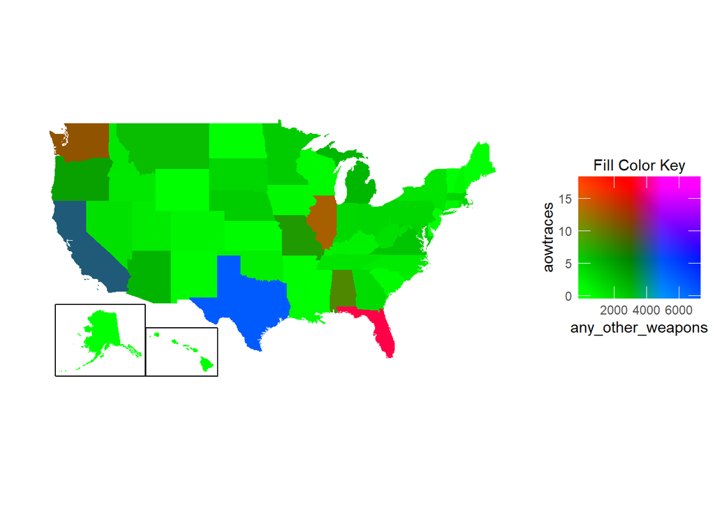

```r
p <- ggplot(nfa_items_by_state, aes(map_id = state)) +
  geom_map(aes(fill = any_other_weapons), map = fifty_states) +
  expand_limits(x = fifty_states$long, y = fifty_states$lat) +
  coord_map() +
  scale_x_continuous(breaks = NULL) +
  scale_y_continuous(breaks = NULL) +
  labs(x = "", y = "") +
  theme(legend.position = "bottom", panel.background = element_blank())+
  aes(fill2 = aowtraces) + scale_fill_colorplane() +
  theme(legend.position = "right")
p + fifty_states_inset_boxes()
```

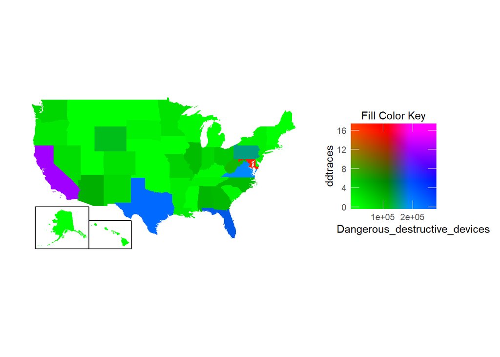

```r
nfa_items_by_state$state <- tolower(nfa_items_by_state$state)
p <- ggplot(nfa_items_by_state, aes(map_id = state)) +
  geom_map(aes(fill = Dangerous_destructive_devices), map = fifty_states) +
  expand_limits(x = fifty_states$long, y = fifty_states$lat) +
  coord_map() +
  scale_x_continuous(breaks = NULL) +
  scale_y_continuous(breaks = NULL) +
  labs(x = "", y = "") +
  theme(legend.position = "bottom",
        panel.background = element_blank())+
  aes(fill2 = ddtraces) + scale_fill_colorplane() +
  theme(legend.position = "right")
p + fifty_states_inset_boxes()
```

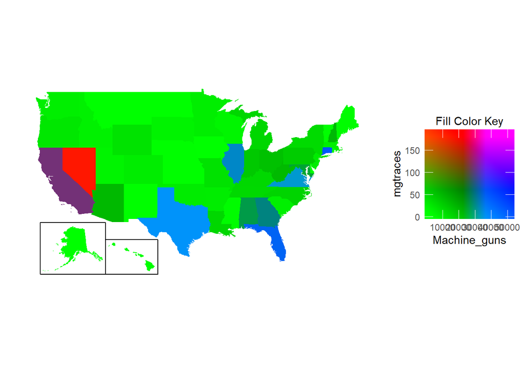

```r
nfa_items_by_state$state <- tolower(nfa_items_by_state$state)
p <- ggplot(nfa_items_by_state, aes(map_id = state)) +
  geom_map(aes(fill = Machine_guns), map = fifty_states) +
  expand_limits(x = fifty_states$long, y = fifty_states$lat) +
  coord_map() +
  scale_x_continuous(breaks = NULL) +
  scale_y_continuous(breaks = NULL) +
  labs(x = "", y = "") +
  theme(legend.position = "bottom",
        panel.background = element_blank())+
  aes(fill2 = mgtraces) + scale_fill_colorplane() +
  theme(legend.position = "right")
p + fifty_states_inset_boxes()
```

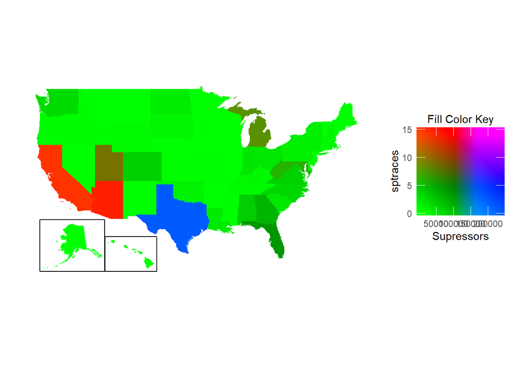

```r
nfa_items_by_state$state <- tolower(nfa_items_by_state$state)
p <- ggplot(nfa_items_by_state, aes(map_id = state)) +
  geom_map(aes(fill = Supressors), map = fifty_states) +
  expand_limits(x = fifty_states$long, y = fifty_states$lat) +
  coord_map() +
  scale_x_continuous(breaks = NULL) +
  scale_y_continuous(breaks = NULL) +
  labs(x = "", y = "") +
  theme(legend.position = "bottom",
        panel.background = element_blank())+
  aes(fill2 = sptraces) + scale_fill_colorplane() +
  theme(legend.position = "right")
p + fifty_states_inset_boxes()
```